# R 중급 통계분석 3일차 (1)

대구대학교(윤상후)

## 단순회귀분석 연습

`slr02.csv` 파일을 불러와 문제를 푸세요.

> Y = chirps/sec for the striped ground cricket

> X = temperature in degrees Fahrenhei
1. 산점도 그리기

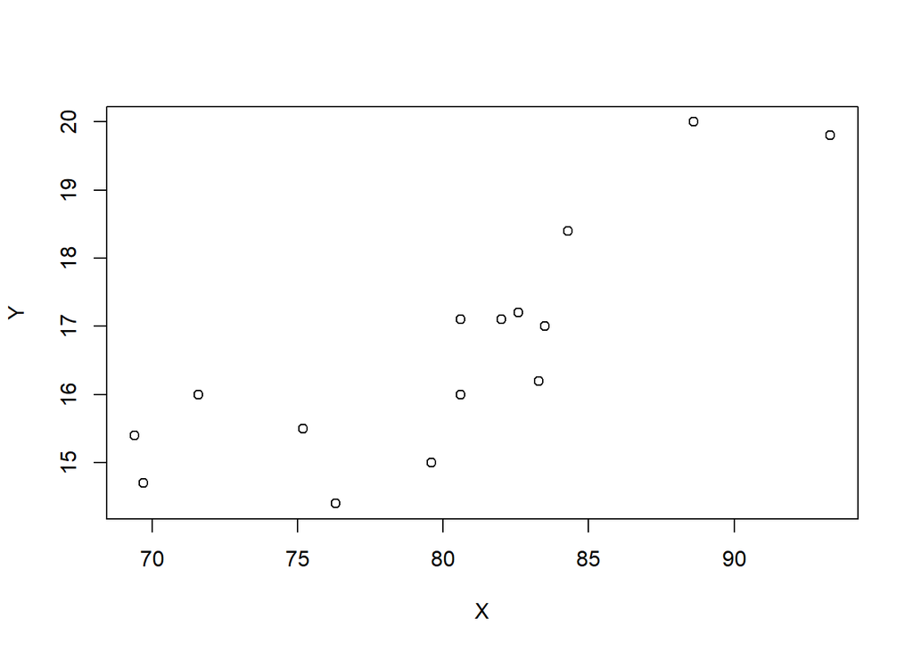

2. 상관계수 그리기

```
##
##  Pearson's product-moment correlation
##
## data:  data$X and data$Y
## t = 5.4745, df = 13, p-value = 0.0001067
## alternative hypothesis: true correlation is not equal to 0
## 95 percent confidence interval:
##  0.5642928 0.9436856
## sample estimates:
##       cor
## 0.8351438
```

3. 회귀모형 세우기

```
##
## Call:
## lm(formula = Y ~ X, data = data)
##
## Residuals:
##      Min       1Q   Median       3Q      Max
## -1.56009 -0.57930  0.03129  0.59020  1.53259
##
## Coefficients:
##             Estimate Std. Error t value Pr(>|t|)
## (Intercept) -0.30914    3.10858  -0.099 0.922300
## X            0.21192    0.03871   5.475 0.000107 ***
## ---
## Signif. codes:  0 '***' 0.001 '**' 0.01 '*' 0.05 '.' 0.1 ' ' 1
##
## Residual standard error: 0.9715 on 13 degrees of freedom
## Multiple R-squared:  0.6975, Adjusted R-squared:  0.6742
## F-statistic: 29.97 on 1 and 13 DF,  p-value: 0.0001067
```

4. 회귀가정 확인하기

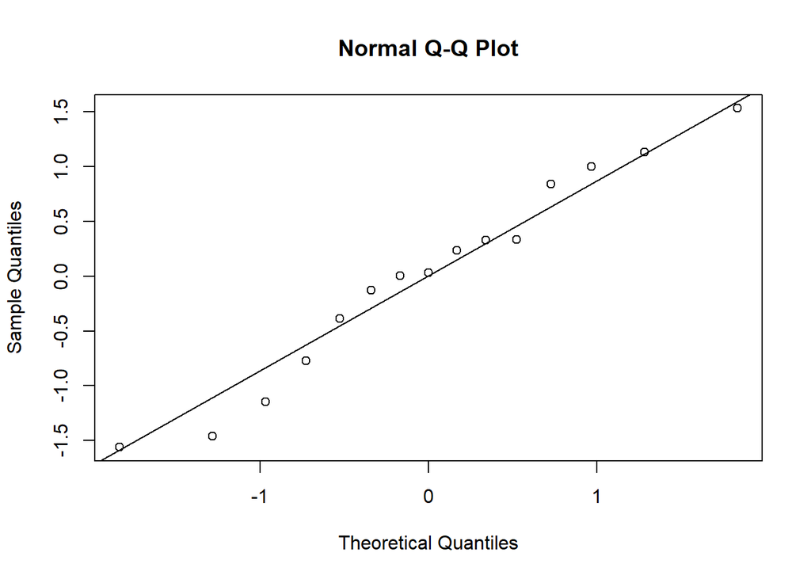

```
##
##  Shapiro-Wilk normality test
##
## data:  reg1$residuals
## W = 0.9632, p-value = 0.7478
```

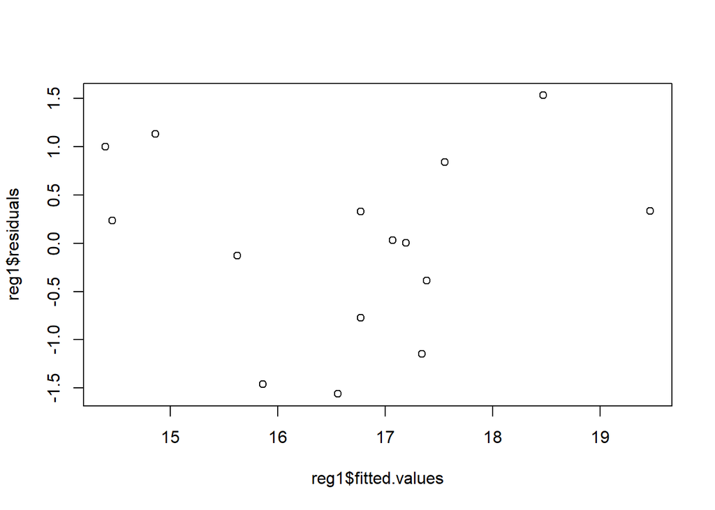

```
##  lag Autocorrelation D-W Statistic p-value
##    1       0.3375696     0.9595329   0.034
##  Alternative hypothesis: rho != 0
```

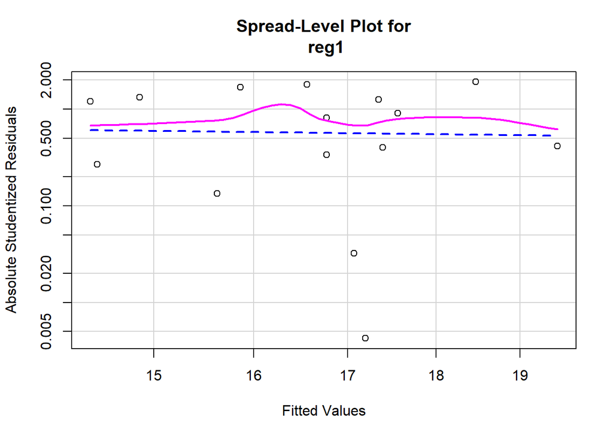

```
##
## Suggested power transformation:  1.410213
```

```
## Non-constant Variance Score Test
## Variance formula: ~ fitted.values
## Chisquare = 0.002475841, Df = 1, p = 0.96032
```

5. 회귀진단하기

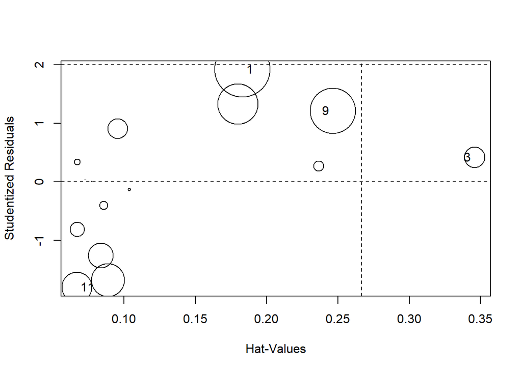

```
##       StudRes        Hat      CookD
## 1   1.9162712 0.18300419 0.34114689
## 3   0.4144248 0.34583083 0.04848703
## 9   1.2083923 0.24641114 0.23057023
## 11 -1.7999962 0.06697405 0.09919386
```

6. 영향점 1개를 제거 후 재분석해보기

```
##
## Call:
## lm(formula = Y ~ X, data = data2)
##
## Residuals:
##     Min      1Q  Median      3Q     Max
## -1.4462 -0.5178  0.1469  0.7166  1.0775
##
## Coefficients:
##             Estimate Std. Error t value Pr(>|t|)
## (Intercept)  1.60640    3.00249   0.535 0.602407
## X            0.18643    0.03768   4.947 0.000338 ***
## ---
## Signif. codes:  0 '***' 0.001 '**' 0.01 '*' 0.05 '.' 0.1 ' ' 1
##
## Residual standard error: 0.8848 on 12 degrees of freedom
## Multiple R-squared:  0.671,  Adjusted R-squared:  0.6436
## F-statistic: 24.48 on 1 and 12 DF,  p-value: 0.0003379
```

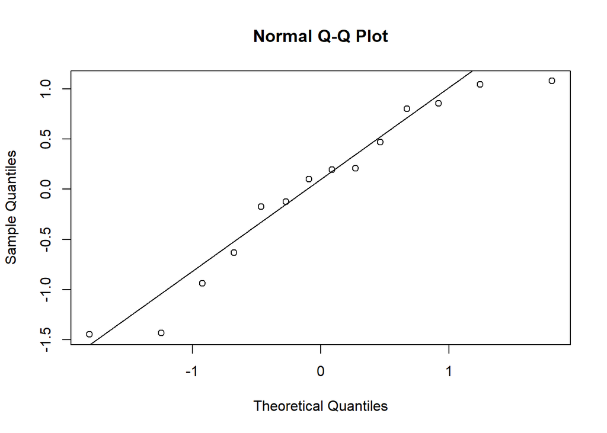

```
##
##  Shapiro-Wilk normality test
##
## data:  reg2$residuals
## W = 0.92716, p-value = 0.2783
```

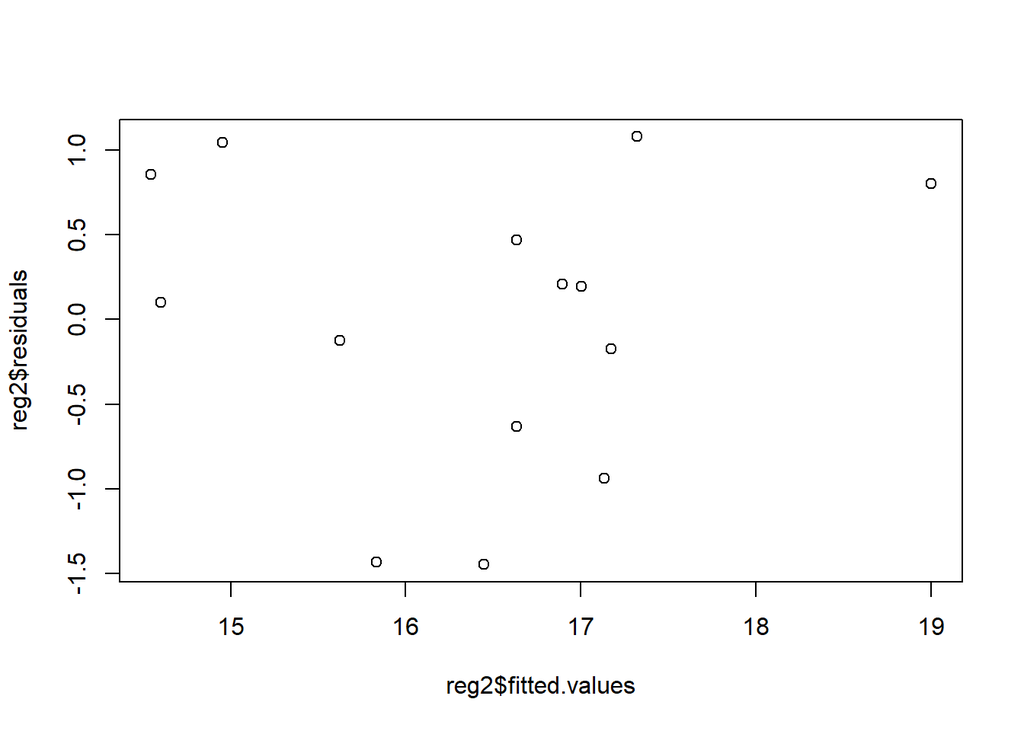

```
##  lag Autocorrelation D-W Statistic p-value
##    1       0.3015569      1.062639   0.068
##  Alternative hypothesis: rho != 0
```

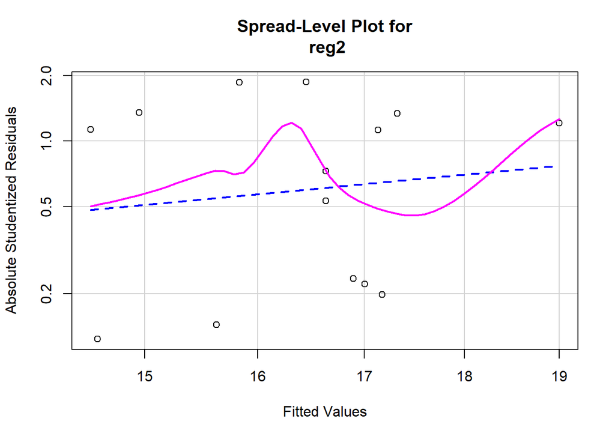

```
##
## Suggested power transformation:  -0.7521395
```

```
## Non-constant Variance Score Test
## Variance formula: ~ fitted.values
## Chisquare = 0.01942704, Df = 1, p = 0.88915
```

7. 회귀분석 결과 시각화 해보기

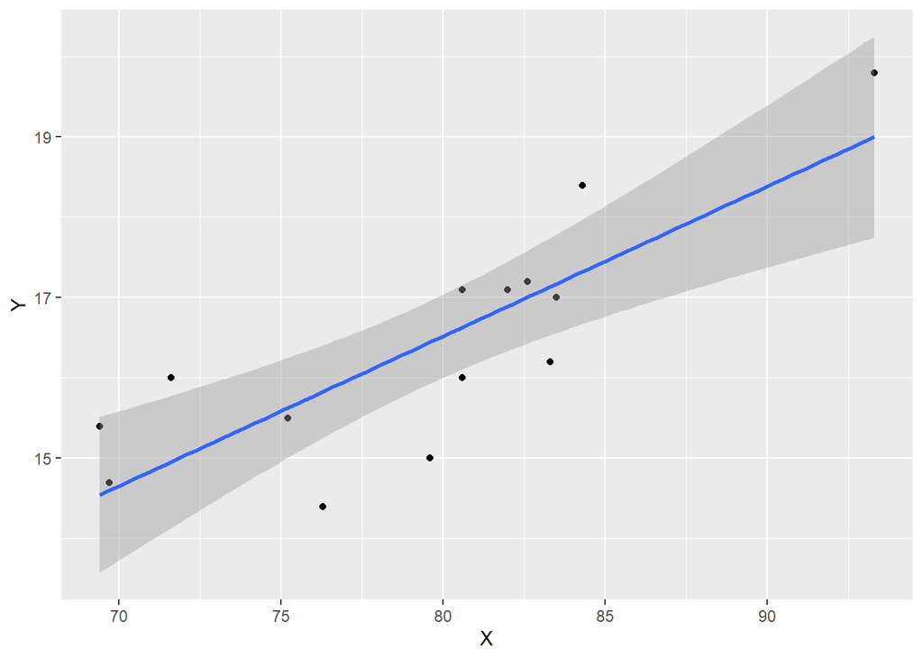

8. 화씨 90도, 100도 일 때, 귀뚜라미 초당 진동수와 95% 신뢰구간은?

```
##        fit      lwr      upr
## 1 18.38512 17.37573 19.39450
## 2 20.24942 18.48355 22.01529
```

`mlr10.csv` 파일을 불러와 문제를 푸세요.

> Denver Neighborhoods

> The data (X1, X2, X3, X4, X5, X6, X7) are for each neighborhood

> X1 = total population (in thousands)

> X2 = % change in population over past several years

> X3 = % of children (under 18) in population

> X4 = % free school lunch participation

> X5 = % change in household income over past several years

> X6 = crime rate (per 1000 population)

> X7 = % change in crime rate over past several years

> Reference: The Piton Foundation, Denver, Colorado

X6를 종속변수, 나머지 변수를 독립변수로 사용한 다중회귀모형을 세워보세요.

```
##
## Call:
## lm(formula = X6 ~ ., data = data)
##
## Residuals:
##      Min       1Q   Median       3Q      Max
## -117.010  -37.285   -2.292   28.046  241.633
##
## Coefficients:
##             Estimate Std. Error t value Pr(>|t|)
## (Intercept)  67.5618    58.8035   1.149   0.2580
## X1           -5.2679     3.1061  -1.696   0.0983 .
## X2            1.2279     0.9558   1.285   0.2069
## X3           -7.0990     1.6171  -4.390 9.11e-05 ***
## X4            2.8437     0.5304   5.361 4.60e-06 ***
## X5            4.5877     1.6586   2.766   0.0088 **
## X7            0.5862     0.7550   0.776   0.4424
## ---
## Signif. codes:  0 '***' 0.001 '**' 0.01 '*' 0.05 '.' 0.1 ' ' 1
##
## Residual standard error: 66.18 on 37 degrees of freedom
##   (10 observations deleted due to missingness)
## Multiple R-squared:  0.658,  Adjusted R-squared:  0.6025
## F-statistic: 11.86 on 6 and 37 DF,  p-value: 2.187e-07
```

1. 다중공선성의 문제는 없나요?

```
##       X1       X2       X3       X4       X5       X7
## 1.196931 1.336217 2.015374 1.850851 1.239400 1.809932
```

2. 후진제거법으로 변수선택을 한다면 최적모형은?

```
## Start:  AIC=375.3
## X6 ~ X1 + X2 + X3 + X4 + X5 + X7
##
##        Df Sum of Sq    RSS    AIC
## - X7    1      2641 164684 374.01
## - X2    1      7227 169270 375.22
## <none>              162043 375.30
## - X1    1     12597 174640 376.60
## - X5    1     33508 195551 381.57
## - X3    1     84406 246449 391.75
## - X4    1    125875 287918 398.59
##
## Step:  AIC=374.01
## X6 ~ X1 + X2 + X3 + X4 + X5
##
##        Df Sum of Sq    RSS    AIC
## <none>              164684 374.01
## - X2    1      9351 174035 374.44
## - X1    1     18060 182744 376.59
## - X5    1     32178 196862 379.87
## - X3    1    102079 266762 393.24
## - X4    1    154310 318994 401.10
```

3. 회귀모형의 가설을 만족하는지 확인하세요.

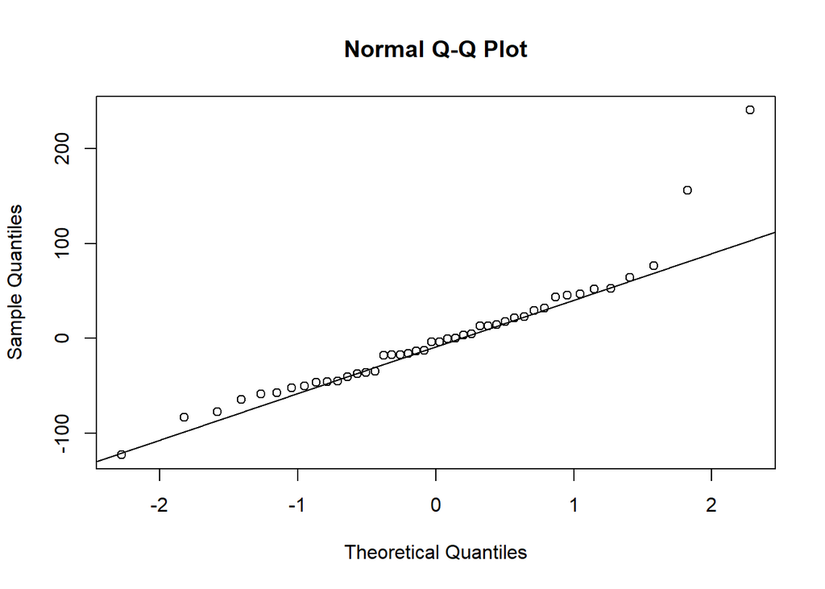

```
##
##  Shapiro-Wilk normality test
##
## data:  mreg1$residuals
## W = 0.8959, p-value = 0.0008159
```

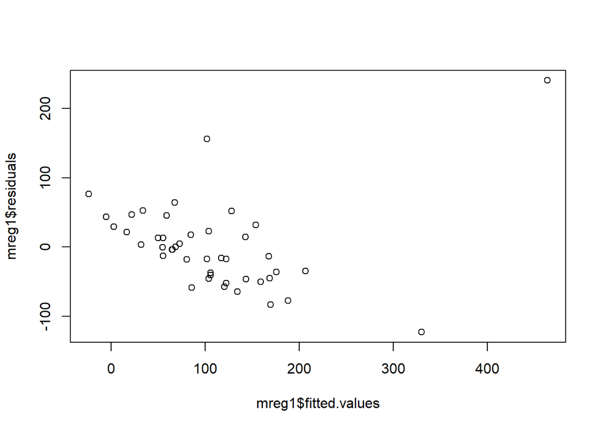

```
##  lag Autocorrelation D-W Statistic p-value
##    1      -0.1245621      2.230487   0.502
##  Alternative hypothesis: rho != 0
```

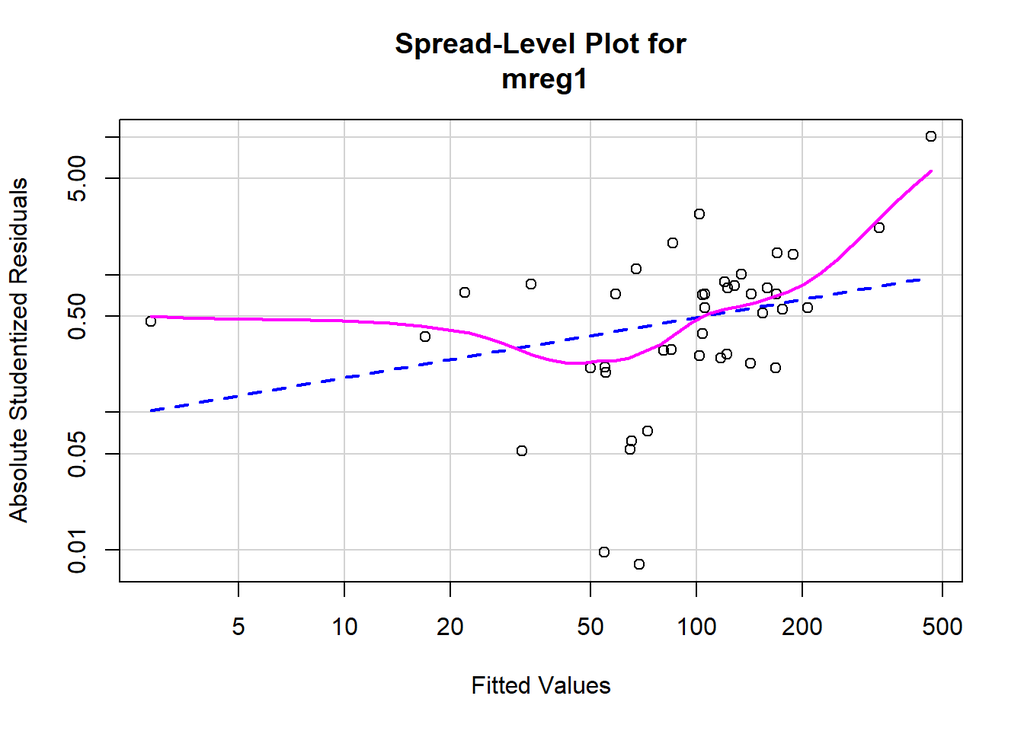

```
##
## Suggested power transformation:  0.5619491
```

```
## Non-constant Variance Score Test
## Variance formula: ~ fitted.values
## Chisquare = 63.49413, Df = 1, p = 1.6085e-15
```

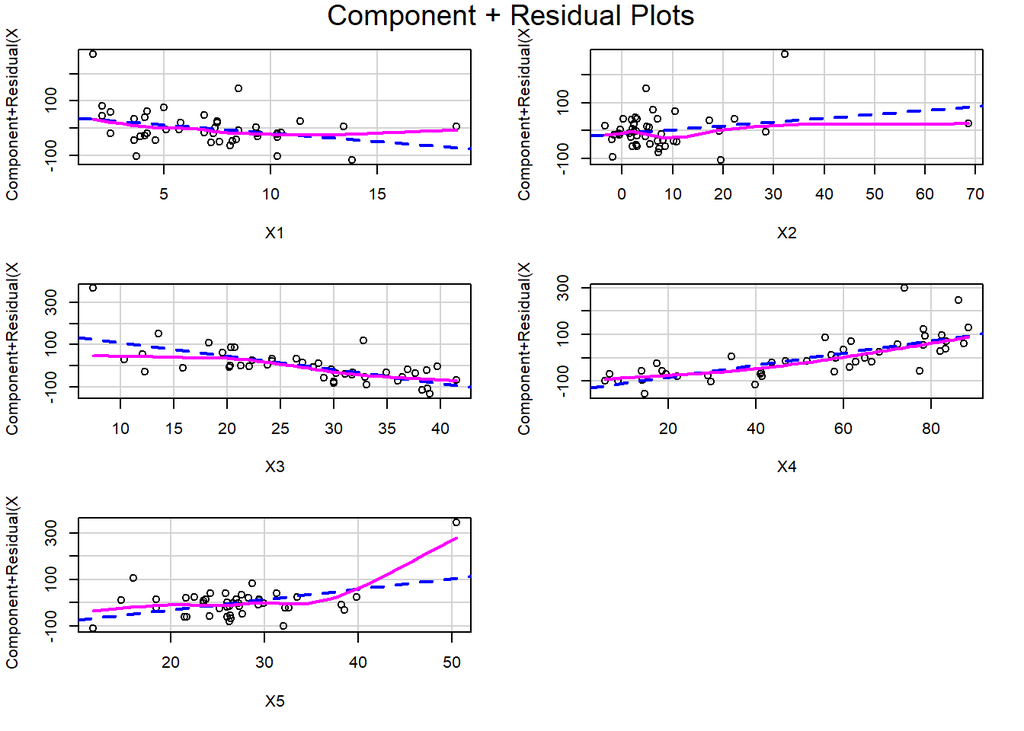

4. 회귀진단을 한다면?

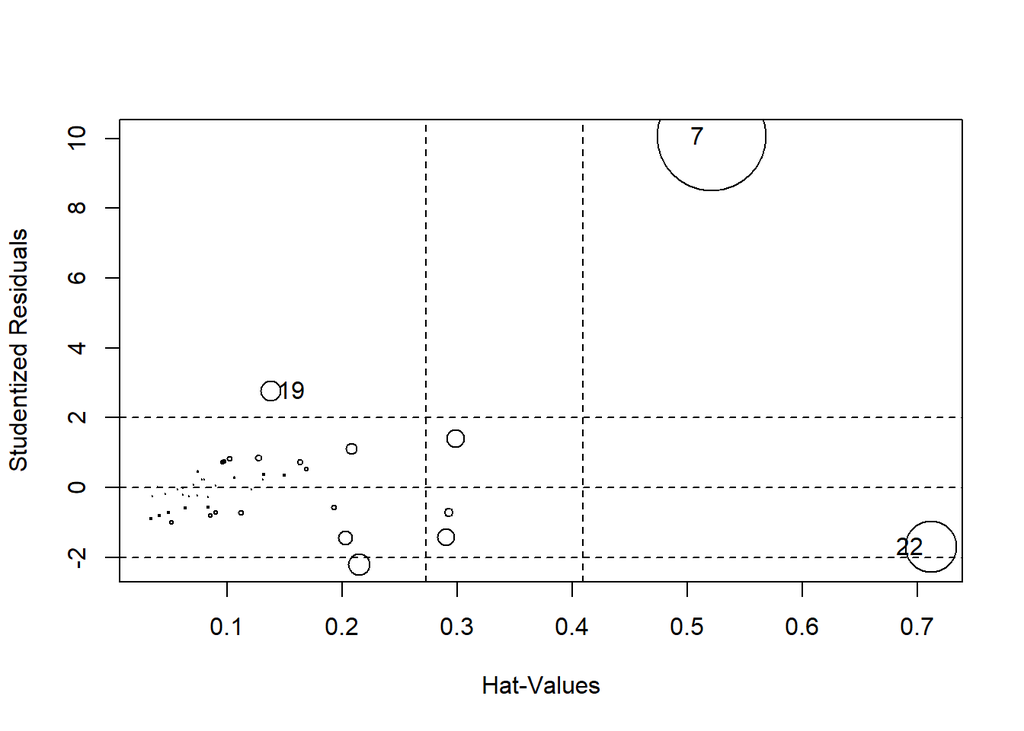

```
##      StudRes       Hat     CookD
## 7  10.047181 0.5209871 5.0407124
## 19  2.765368 0.1376464 0.1731501
## 22 -1.697004 0.7115155 1.1279944
```